# HW0: Python Installation, Set and Review of CS133

## CS 233 Essentials of Data Science

## Objectives

- Review how to use "**datasciece**" (note: not Pandas) package used in CS133
- Learn how to run and use Jupyter Lab on your own computer
- Learn how to save .ipynb and .html files in Jupyter Lab

## This HW is worth 10 points.

## To you help you get through the problems, **some outputs are deliberately presented included in this notebook**.

- ? marks indicate placeholders to be relaced by your real codes
- ? marks may require more than one line of codes.

**Note:** if you didn't learn "datascience" package but "pandas" from your CS133 session, you can revise the following header by import pandas to solve this HW.

```python
# Run this cell to set up the notebook, but please don't change it.
# These lines import the Numpy and Datascience modules.
## Just to be clear, I think I understood the header correctly, and I used Pandas since that's what I learned in my 133 section. Thanks!
import numpy as np
import pandas as pd

# These lines do some fancy plotting magic.
import matplotlib
%matplotlib inline
import matplotlib.pyplot as plt
plt.style.use('fivethirtyeight')
import warnings
warnings.simplefilter('ignore', FutureWarning)
```

## Data Analsyis: Child Race Data

### a. Load Data

**Question 1. (pt 2)** :

Load data from the file *children_raw.csv* into a *Table* called `raw_child_data`.

```python
raw_child_data = pd.read_csv("children_raw.csv").set_index('State')
raw_child_data
```

| State | White | Black | Hispanic | Other | Total |
| --- | --- | --- | --- | --- | --- |
| Alabama | 712200 | 362100 | 76100 | 36700 | 1187100 |
| Alaska | 88600 | 5000 | 23100 | 75800 | 192600 |
| Arizona | 571200 | 60000 | 936800 | 159600 | 1727500 |
| Arkansas | 463800 | 134000 | 75800 | 62000 | 735700 |
| California | 2786000 | 484200 | 4849400 | 1590100 | 9709700 |
| Colorado | 740500 | 66400 | 422900 | 116500 | 1346300 |
| Connecticut | 523600 | 71500 | 175400 | 72500 | 843000 |
| Delaware | 112600 | 48300 | 37300 | 17700 | 215800 |
| District of Columbia | 31200 | 68800 | 18000 | 5700 | 123800 |
| Florida | 1944100 | 905700 | 1327300 | 214100 | 4391100 |
| Georgia | 1142400 | 883100 | 404200 | 184900 | 2614600 |
| Hawaii | 37700 | 0 | 50700 | 246100 | 338300 |
| Idaho | 351100 | 0 | 87000 | 25400 | 466700 |
| Illinois | 1734800 | 438600 | 712800 | 250000 | 3136200 |
| Indiana | 1197100 | 215200 | 231600 | 79600 | 1723500 |
| Iowa | 641000 | 34100 | 77000 | 41900 | 793900 |
| Kansas | 493700 | 41200 | 137200 | 76000 | 748100 |
| Kentucky | 770600 | 111200 | 83000 | 71500 | 1036300 |
| Louisiana | 574700 | 418200 | 107300 | 63300 | 1163400 |
| Maine | 243400 | 0 | 0 | 20500 | 276600 |
| Maryland | 647900 | 463600 | 180000 | 159200 | 1450700 |
| Massachusetts | 937600 | 133600 | 251000 | 181600 | 1503800 |
| Michigan | 1430100 | 378400 | 208100 | 232600 | 2249100 |
| Minnesota | 944500 | 108200 | 107600 | 200200 | 1360400 |
| Mississippi | 385700 | 318800 | 32800 | 0 | 757700 |
| Missouri | 1132000 | 194000 | 103600 | 84400 | 1514000 |
| Montana | 206200 | 2300 | 13700 | 18300 | 240500 |
| Nebraska | 345000 | 30400 | 83200 | 34800 | 493400 |
| Nevada | 250300 | 86200 | 275400 | 89700 | 701600 |
| New Hampshire | 248500 | 0 | 15400 | 11800 | 279500 |
| New Jersey | 1073700 | 340900 | 490200 | 213200 | 2118000 |
| New Mexico | 139900 | 7700 | 274100 | 105100 | 526700 |
| New York | 2183800 | 686600 | 1036000 | 593300 | 4499700 |
| North Carolina | 1295900 | 554100 | 366100 | 231300 | 2447400 |
| North Dakota | 148500 | 6800 | 8600 | 18900 | 182700 |
| Ohio | 1975900 | 397400 | 150000 | 246100 | 2769500 |
| Oklahoma | 535600 | 95800 | 170000 | 221300 | 1022700 |
| Oregon | 615600 | 0 | 176000 | 121000 | 930300 |
| Pennsylvania | 1932700 | 363300 | 378700 | 212700 | 2887300 |
| Rhode Island | 153200 | 14500 | 42600 | 16900 | 227200 |
| South Carolina | 647200 | 332300 | 98900 | 65200 | 1143600 |
| South Dakota | 162700 | 4200 | 8700 | 41800 | 217400 |
| Tennessee | 1038100 | 300100 | 158500 | 79800 | 1576600 |
| Texas | 2486600 | 942100 | 3570000 | 467800 | 7466600 |
| Utah | 731300 | 16600 | 145900 | 54200 | 948100 |
| Vermont | 114200 | 3200 | 0 | 6700 | 126500 |
| Virginia | 1150400 | 417100 | 248800 | 214500 | 2030800 |
| Washington | 996600 | 81400 | 396400 | 290200 | 1764700 |
| West Virginia | 338600 | 17000 | 0 | 26900 | 388400 |
| Wisconsin | 971800 | 113600 | 191100 | 104100 | 1380500 |
| Wyoming | 117100 | 0 | 18500 | 5600 | 143300 |

**Question 2. (pt 2)** :

Create new table called `child_data` that uses data from `raw_child_data` to calculate what fraction each race represents in the child population for each state. The columns in the new table should be called `Fraction White`, `Fraction Black`, etc.

```python
child_data = raw_child_data.drop(columns=["Total"]).div(raw_child_data['Total'], axis=0)
child_data.columns = ['Fraction ' + col for col in child_data.columns]
child_data
```

| State | Fraction White | Fraction Black | Fraction Hispanic | Fraction Other |
| --- | --- | --- | --- | --- |
| Alabama | 0.599949 | 0.305029 | 0.064106 | 0.030916 |
| Alaska | 0.460021 | 0.025961 | 0.119938 | 0.393562 |
| Arizona | 0.330651 | 0.034732 | 0.542287 | 0.092388 |
| Arkansas | 0.630420 | 0.182139 | 0.103031 | 0.084273 |
| California | 0.286930 | 0.049868 | 0.499439 | 0.163764 |
| Colorado | 0.550026 | 0.049320 | 0.314120 | 0.086533 |
| Connecticut | 0.621115 | 0.084816 | 0.208066 | 0.086002 |
| Delaware | 0.521779 | 0.223818 | 0.172845 | 0.082020 |
| District of Columbia | 0.252019 | 0.555735 | 0.145396 | 0.046042 |
| Florida | 0.442736 | 0.206258 | 0.302271 | 0.048758 |
| Georgia | 0.436931 | 0.337757 | 0.154593 | 0.070718 |
| Hawaii | 0.111440 | 0.000000 | 0.149867 | 0.727461 |
| Idaho | 0.752303 | 0.000000 | 0.186415 | 0.054425 |
| Illinois | 0.553153 | 0.139851 | 0.227281 | 0.079714 |
| Indiana | 0.694575 | 0.124862 | 0.134378 | 0.046185 |
| Iowa | 0.807406 | 0.042953 | 0.096990 | 0.052777 |
| Kansas | 0.659939 | 0.055073 | 0.183398 | 0.101591 |
| Kentucky | 0.743607 | 0.107305 | 0.080093 | 0.068995 |
| Louisiana | 0.493983 | 0.359464 | 0.092230 | 0.054409 |
| Maine | 0.879971 | 0.000000 | 0.000000 | 0.074114 |
| Maryland | 0.446612 | 0.319570 | 0.124078 | 0.109740 |
| Massachusetts | 0.623487 | 0.088842 | 0.166910 | 0.120761 |
| Michigan | 0.635854 | 0.168245 | 0.092526 | 0.103419 |
| Minnesota | 0.694281 | 0.079535 | 0.079094 | 0.147163 |
| Mississippi | 0.509041 | 0.420747 | 0.043289 | 0.000000 |
| Missouri | 0.747688 | 0.128137 | 0.068428 | 0.055746 |
| Montana | 0.857380 | 0.009563 | 0.056965 | 0.076091 |
| Nebraska | 0.699230 | 0.061613 | 0.168626 | 0.070531 |
| Nevada | 0.356756 | 0.122862 | 0.392531 | 0.127851 |
| New Hampshire | 0.889088 | 0.000000 | 0.055098 | 0.042218 |
| New Jersey | 0.506941 | 0.160954 | 0.231445 | 0.100661 |
| New Mexico | 0.265616 | 0.014619 | 0.520410 | 0.199544 |
| New York | 0.485321 | 0.152588 | 0.230238 | 0.131853 |
| North Carolina | 0.529501 | 0.226404 | 0.149587 | 0.094508 |
| North Dakota | 0.812808 | 0.037219 | 0.047072 | 0.103448 |
| Ohio | 0.713450 | 0.143492 | 0.054161 | 0.088861 |
| Oklahoma | 0.523712 | 0.093674 | 0.166227 | 0.216388 |
| Oregon | 0.661722 | 0.000000 | 0.189186 | 0.130066 |
| Pennsylvania | 0.669380 | 0.125827 | 0.131161 | 0.073667 |
| Rhode Island | 0.674296 | 0.063820 | 0.187500 | 0.074384 |
| South Carolina | 0.565932 | 0.290574 | 0.086481 | 0.057013 |
| South Dakota | 0.748390 | 0.019319 | 0.040018 | 0.192272 |
| Tennessee | 0.658442 | 0.190346 | 0.100533 | 0.050615 |
| Texas | 0.333030 | 0.126175 | 0.478129 | 0.062652 |
| Utah | 0.771332 | 0.017509 | 0.153887 | 0.057167 |
| Vermont | 0.902767 | 0.025296 | 0.000000 | 0.052964 |
| Virginia | 0.566476 | 0.205387 | 0.122513 | 0.105623 |
| Washington | 0.564742 | 0.046127 | 0.224627 | 0.164447 |
| West Virginia | 0.871782 | 0.043769 | 0.000000 | 0.069258 |
| Wisconsin | 0.703948 | 0.082289 | 0.138428 | 0.075407 |
| Wyoming | 0.817167 | 0.000000 | 0.129100 | 0.039079 |

### b. Analyze Data

Draw a barchart with the fraction of the child populations that are hispanic.

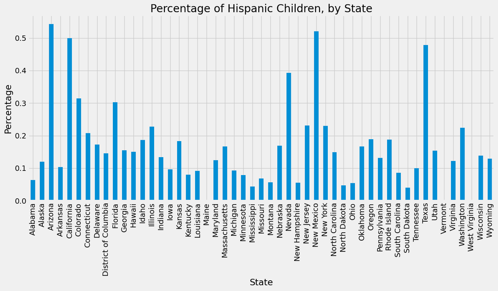

```python
child_data['Fraction Hispanic'].plot(kind='bar', figsize=(14,6), ylabel='Percentage', title="Percentage of Hispanic Children, by State")
```

**Question 3. (pt 2)** :

Using the plot, which state, excluding the District of Columbia, has the highest fraction of children that are hispanic?

Arizona

**Question 4. (pt 2)** :

Confirm this using Python code. The `?` is just a placeholder. You may need more lines of code.

```python
highest_frac_hispanic = child_data['Fraction Hispanic'].idxmax()
highest_frac_hispanic
```

```
'Arizona'
```

**Question 5. (pt 2)** :

What fraction of the child population rounded to two decimal places is hispanic in this state?

```python
frac_hispanic = round(child_data['Fraction Hispanic'].max(), 2)

frac_hispanic
```

```
np.float64(0.54)
```